# Assignment 2

This assignment consists of two parts. In the first part you will explore the iris flower dataset that is built into R. You can use the command `?iris` in R if you want to get some information about the dataset.

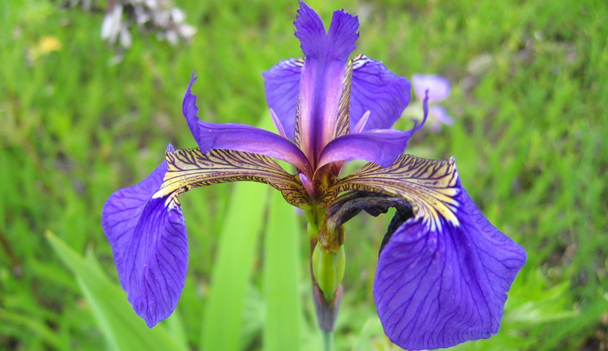

In the second part, we will look for important factors for predicting diabetes in Pima Indian women. You can find the dataset on canvas [here](https://www.canvas.umu.se/courses/11149/pages/diabetes-data?module_item_id=470234).

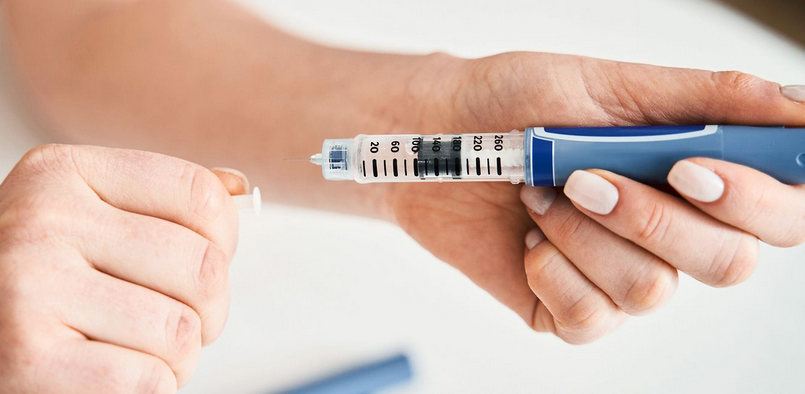

Your assignment tasks are the provided below. Answer the indented question to each numbered task in a comment below your code using `#`. Note that the auto-corrector only tests your code, not your question responses.

### Part 1

1. Compute the correlations between all numeric variables in the dataset. Save the result in a variable called `correlations`.
   - Are the correlations positive or negative? Does this make sense to you?
2. Use ggplot to create a scatterplot with the sepal width on the x axis against the sepal height on the y axis. Save the resulting plot in a variable called `plot1`.
   - How does the plotted points match the correlations we computed before?
3. Fit a linear regression model predicting the sepal length using sepal width. Save the model is a variable called `model1`.
   - Does the estimated coefficient for sepal width match what have seen in tasks 1 and 2?
4. Compute the correlations between all numeric variables in the dataset *using only the setosas*. Save the result in a variable called `correlations_setosa`.
   - Are these correlations positive or negative? How are they different from the overall correlations? Does this make sense?
5. Use ggplot to create a scatterplot with the sepal width on the x axis against the sepal height on the y axis. Color the points by flower species. Save the resulting plot in a variable called `plot2`
   - Does this match the correlations we computed for setosa flowers?
6. Fit a linear regression model predicting the sepal length using sepal width and the flower species. Save the model is a variable called `model2`.
   - Does the estimated coefficient for Sepal.Width make sense? What happened when we added species to our model? How does it change the interpretation?
7. Predict the sepal length of a setosa with a sepal width of 3.6 cm using your second model. Save the resulting prediction in a variable called `prediction`.
   - Does the prediction appear reasonable?

### Part 2

8. Load the Pima Indian Diabetes dataset into a tibble or data frame called `diabetes_data`.
   - *Important*: Store the file in your working directory and do not rename it. Otherwise the auto-corrector will not find it on the server when running your code.
   - *Important*: Do not recode or rename any of your variables for task 9 and 10. Maybe you can improve your model by doing it so it is not bad practice, but it will cause the auto-corrector to fail.
9. Fit a logistic regression model to predict whether or not a Pima Indian woman has diabetes. Use plots and descriptive statistics, predictor significance and AIC to find good predictors and create a good model. Store the final model in a variable called `logistic_model`.
   - Which variables are strongly related to diabetes? Do the effects in your model appear reasonable?
10. Make sure your model from task 9 can predict whether or not someone has diabetes in more than 76.5% of cases in the dataset using a classification threshold of 50% (a predicted probability of above 50% predicts diabetes). All the variables in your model must show significant relationships with diabetes on a 5% significance level. Save the prediction accuracy in a numeric variable called `accuracy`.
    - Here we used the same data for fitting the regression model and evaluate the prediction accuracy of the fitted model. This is simple but not always good. Reflect on why this may be the case. Use google, chatGPT, YouTube or other sources to find out why if you have no idea (You don’t need to to change your code).
11. Make sure your R script runs from top to bottom after clearing the environment and restarting R/RStudio.

We have prepared a “skeleton” of the assignment code below. Save this as your own .R script and submit it through canvas after testing it in the [auto-corrector](https://statistics-umu.shinyapps.io/data-analytics-with-r/). **Make sure you do not overwrite or modify any of the variables below later in your code after completing each task**. It will cause the auto-corrector to fail.

```r
# 1. Correlations
correlations <- ...
# Answer to question 1...

# 2. Plot Sepal.Width against Sepal.Length
plot1 <- ...
# Answer to question 2...

# 3. Fit a linear model using Sepal.Width as predictor and Sepal.Length as response
model1 <- ...
# Answer to question 3...

# 4. Setosa correlations
correlations_setosa <- ...
# Answer to question 4...

# 5. Plot Sepal.Width against Sepal.Length, color by species
plot2 <- ...
# Answer to question 5...

# 6. Fit second model using species and Sepal.Width as predictors and Sepal.Length as response
model2 <- ...
# Answer to question 6...

# 7. Predict the sepal length of a setosa with a sepal width of 3.6 cm
prediction <- ...
# Answer to question 7...

# 8. Load the Pima Indian diabetes .csv into R
diabetes_data <- ...

# 9. Find a good logistic regression model
...
explore the data and various models
...
logistic_model <- ...

# 10. Compute the accuracy
accuracy <- ...
```

Good luck with the assignment!